# Analysis: bodyfat prediction

- Show All Code
- Hide All Code
- View Source

2024

Contrast-Bayes-Frequentist

STRATOS

R

Classification: confidential

Author

Affiliation

Georg Heinze

Medical University of Vienna, Center for Medical Data Science

Published

June 13, 2025

## 0.1 Load libraries

```r
library(mfp2)

library(here)
library(dplyr)
library(tidyr)
library(ggplot2)
library(tidyselect)
library(gt)
library(gtExtras)
library(patchwork)
library(Hmisc)
library(sjlabelled)
```

# 1 Model estimation

## 1.1 Load data

```r
load("Datafiles/bodyfatdata.Rdata")
```

## 1.2 Initial data analysis for women data

The description of the IDA plan follows the example in [Regression without regrets](https://stratosida.github.io/regression-regrets/) which accompanies the paper of [Heinze et al (2024)](https://doi.org/10.21203/rs.3.rs-3580334/v1).

### 1.2.1 Prerequisites

#### 1.2.1.1 PRE1: research aim

We fit a prediction model for bodyfat using anthropometric measures.

#### 1.2.1.2 PRE2: analysis strategy

The analysis strategy is described in the Task document.

#### 1.2.1.3 PRE3: analysis ready data dictionary

The source data dictionary of the college women bodyfat data set is described in the Task document.

Here we transform the data into long format for purpose of conducting IDA efficiently.

```r
## transform
women_long <-
  women |>
  mutate(AgeP = Age) |>  ## Create a copy of AGE to store as a predictor
  pivot_longer(
    cols = c(-Obs,-Age,-Fat),
    names_to = "PARAMCD",
    values_to = "AVAL",
    values_drop_na = FALSE
  ) |>
  mutate(PARAMCD = if_else(PARAMCD == "AgeP", "Age", PARAMCD)) ## rename AGE param code
```

#### 1.2.1.4 PRE4: domain expertise

- Age is chosen as the single structural variable.
- Waist, Height and Weight are the key predictors for IDA.
- Fat is the dependent variable.
- All other predictors (BMI, Neck, Chest, Calf, Biceps, Hips, Waist, Forearm, PThigh, MThigh, DThigh, Wrist, Knee, Elbox, Ankle) take on the role of remaining predictor variables.

### 1.2.2 IDA domain M: missing values

There are no missing values in this data set.

### 1.2.3 IDA Domain U: univariate descriptions

Since there only continuous predictors and a continuous outcome variable involved, we will only consider subdomain U2: continuous variables.

#### 1.2.3.1 Structural variable and key predictors

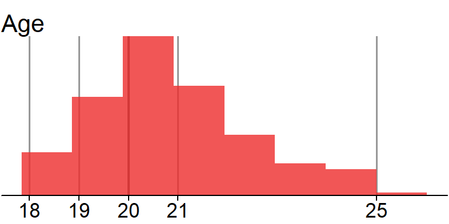

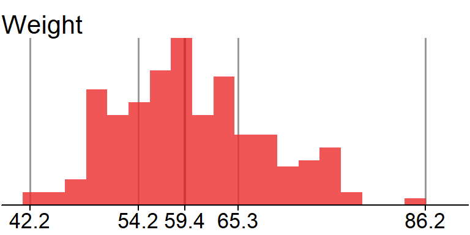

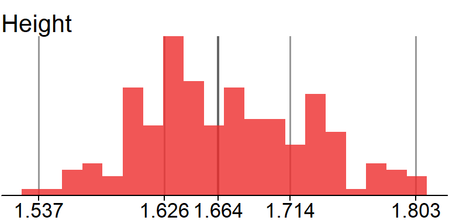